# Rapport Projet Stat App

Travail de groupe

04 May 2026

# 1 Introduction

L’activité d’assurance repose sur un mécanisme de production inversé : l’assureur perçoit les primes avant de connaître avec certitude le montant réel des dépenses qu’il devra engager. En effet, celui-ci est lié à l’assuré par une promesse d’indemnisation en cas de réalisation du risque couvert. Le maintien d’un tel système nécessite donc un renforcement constant des dispositifs de contrôle de la capacité des assureurs à honorer leurs engagements. C’est dans cette perspective que s’inscrit le cadre réglementaire de Solvabilité II, entré en vigueur en 2016, dont l’objectif principal est de garantir que les compagnies d’assurance disposent de fonds propres suffisants pour faire face à leurs obligations et ainsi instaurer un climat de confiance entre assureurs et assurés.

La solvabilité d’une compagnie d’assurance désigne sa capacité à respecter ses engagements financiers à court, moyen et long terme, notamment en matière de règlement des sinistres et de prestations contractuelles. Elle constitue ainsi un indicateur fondamental de la solidité financière des assureurs. Toutefois, cette solvabilité demeure fortement influencée par l’environnement économique et financier. Par exemple, une hausse du taux d’inflation peut entraîner une augmentation mécanique du coût des sinistres, tandis qu’une variation des taux d’intérêt affecte à la fois les perspectives de rendement des placements financiers et la valorisation des obligations détenues par les compagnies d’assurance.

Dans un contexte marqué par la volatilité des marchés financiers, les risques de perturbation des chaînes de valeur économiques, ainsi que le renforcement des exigences prudentielles, il devient essentiel de mieux comprendre les déterminants de la solvabilité des entreprises d’assurance. Cette problématique est d’autant plus importante que la stabilité et la pérennité du secteur assurantiel en dépendent directement.

Le présent travail a donc pour objectif d’évaluer l’impact des variables financières et macroéconomiques sur la solvabilité des entreprises d’assurance en France. Plus précisément, il s’agira d’identifier les variables les plus significatives et de mesurer leur influence sur la solidité financière des assureurs. La résolution de cette problématique reposera sur la mobilisation d’outils économétriques appliqués à des données financières, macroéconomiques et à des indicateurs de solvabilité propres au secteur de l’assurance.

Cette étude permettra notamment d’apprécier le degré de dépendance de la solvabilité des assureurs vis-à-vis des variables macro-financières. Elle constitue ainsi un outil d’aide à la décision pour les compagnies d’assurance, les décideurs publics ainsi que les autorités de régulation prudentielle.

# 2 Révue de la littérature

Les assureurs jouent un rôle majeur dans le système financier en tant qu’investisseurs institutionnels et leur exposition aux différents risques est structurante pour leur solvabilité. Dans le cadre prudentiel Solvabilité II, la sensibilité des fonds propres aux variations des taux, des marchés actions et plus généralement de la conjoncture économique est fortement encadrée. Cette revue de littérature vise à synthétiser les principaux résultats existants.

## 2.1 Impact des taux d’intérêt et du marché obligataire sur la solvabilité des assureurs

La longue durée des engagements d’assurance rend ces entreprises particulièrement sensibles à la structure par terme des taux. Les stress tests réalisés par l’EIOPA mettent en évidence une forte sensibilité des entreprises européennes d’assurance aux chocs de marché, révélant l’exposition directe du SCR aux variations de taux. L’environnement prolongé de taux bas a exercé une pression sur la solvabilité et la rentabilité des assureurs notamment à travers leurs fonds propres. La réévaluation des primes de risques suite à la remontée des taux peut ainsi entraîner des pertes importantes dans les portefeuilles obligataires, affectant le ratio de solvabilité (EIOPA, 2018) [1]. Dans le cadre de Solvabilité II, la courbe des taux sans risque utilisée pour actualiser les flux futurs constitue un élément central dans le calcul des provisions Best Estimates. Un abaissement durable de cette courbe entraîne une hausse des provisions, particulièrement pour les passifs de longue duration, ce qui réduit mécaniquement les fonds propres disponibles (Aalala, 2021) [7]. Par ailleurs, Berdin et Gründl (2015) [2] montrent qu’un environnement de faibles taux peut conduire les assureurs à accroître leur exposition à des actifs plus risqués afin de compenser la faiblesse des rendements. Cette réallocation accroît la sensibilité du bilan aux variations de taux d’intérêt. Ces travaux confirment que la gestion actif-passif et la duration des portefeuilles constituent des éléments centraux dans la maîtrise du risque de solvabilité. Enfin, Poufinas et Siopi (2024) [3] mettent en évidence une relation inverse entre le développement du marché obligataire et le ratio de solvabilité. Un marché obligataire plus développé se caractérise par une meilleure liquidité et une meilleure stabilité, conduisant à une hausse de la demande en obligations et accroit leur prix. Cette appréciation de la valeur des obligations peut accroître l’exposition au risque de crédit et de spread, augmentant ainsi le capital réglementaire requis.

##Impact du marché actions, de la volatilité et des corrélations de marché

L’exposition des compagnies d’assurance au marché actions s’est accrue dans un contexte de hausse des taux et d’inflation élevée. Face à cette remontée des taux, l’EIOPA observe une réallocation partielle des portefeuilles vers des actifs plus risqués, notamment les actions, afin de préserver le rendement, au prix d’un besoin accru en capital réglementaire. Les travaux de Baranoff et Sager (2002) [11] montrent qu’une exposition accrue aux risques financiers, notamment actions, crédit et taux, s’accompagne d’un niveau de capital requis plus élevé afin d’absorber la volatilité des marchés. Les fluctuations de la valeur de marché affectent directement les fonds propres et introduisent une volatilité significative dans le ratio de solvabilité (Rapport ACM 2023) [6]. Dans cette logique, les travaux de Pénasse et Dezorme (2021) [5] mettent en évidence un arbitrage entre le rendement espéré des actions et le surplus de SCR imposé par Solvabilité II.

## 2.2 Rôle des variables macroéconomiques : inflation et cycle économique

Au-delà des variables financières, la littérature souligne que la conjoncture macroéconomique, notamment l’inflation et la croissance, exerce un effet significatif sur la solvabilité des assureurs via la profitabilité, le niveau des sinistres et la dynamique des primes. Les travaux récents de l’EIOPA montrent que l’inflation exerce une pression négative sur la valeur réelle et le rendement des actifs non indexés ainsi que sur la rentabilité des assureurs. Pour les assureurs non-vie, elle augmente également le coût des sinistres et des charges d’exploitation. Pour les assureurs vie, une inflation inattendue peut rendre les provisions techniques insuffisantes et dégrader la rentabilité technique, ce qui exerce une pression négative sur la solvabilité (EIOPA, 2023) [9]. L’étude de Gonji et al. (2020) [10] met également en évidence un impact du taux d’inflation et du PIB sur la croissance et la rentabilité des compagnies d’assurance. Une croissance économique soutenue favorise généralement la demande d’assurance et la capacité des assureurs à générer des fonds propres, tandis qu’un ralentissement économique peut dégrader la qualité des actifs et peser sur le ratio de solvabilité.

Dans l’ensemble, la littérature met en évidence le rôle central des variables macro-financières dans la dynamique de solvabilité, avec des effets différenciés selon les branches. Les assureurs Vie apparaissent généralement plus sensibles aux taux et aux marchés financiers en raison de la longue duration de leurs engagements, tandis que la branche Non-Vie semble davantage influencée par l’inflation et le cycle d’exploitation. Notre travail s’inscrit dans cette lignée tout en s’en distinguant sur plusieurs points. D’une part, nous mobilisons des données Solvabilité II françaises sur la période 2016-2025 ce qui permet de travailler dans un cadre réglementaire homogène peu exploité empiriquement. D’autre part, nous combinons trois approches complémentaires — modèle en différences, ARDL et données de panel — afin de capter simultanément les dynamiques de court terme, les relations d’équilibre de long terme et l’hétérogénéité individuelle des assureurs. Enfin, la distinction systématique entre branches Vie et Non-Vie constitue un apport empirique par rapport aux études qui traitent le secteur de façon agrégée.

# 3 Chronologie des évènements

Nous avons réalisé une chronologie des évènements macroéconomiques et macro-financiers entre 2016 et 2025 (période de nos données) ayant impacté la solvabilité et l’activité des assureurs. Cela afin de déceler les variables pertinentes pour notre analyse et afin de déceler des premiers mécanismes dans l’évolution et la sensibilité du ratio de solvabilité aux variables macro-financières. Nous avons relevé trois grandes phases économiques sur cette période. De 2016 à 2020, les assureurs étaient placés dans un environnement de taux d’intérêt très bas qui a exercé une pression négative sur leur ratio de solvabilité. En effet, les revenus obligataires étaient faibles, ce qui a dégradé leur portefeuille d’investissement et il a été plus difficile pour les assureurs vie d’honorer leurs engagements. Suite à cela, l’économie a subi un retournement et un choc inflationniste pendant les années 2021 et 2022 dû à la reprise économique post-COVID-19 et la crise énergétique. Les taux d’intérêt directeurs de la BCE ont rapidement augmenté et l’inflation a explosé. Pour les assureurs, la hausse brutale des taux a entraîné des pertes latentes sur leur portefeuille obligataire, entraînant une baisse des fonds propres et donc une dégradation du ratio de solvabilité. Enfin, durant les dernières années 2023 à 2025, l’économie traverse une période d’instabilité financière et géopolitique. Les marchés financiers sont affectés par plusieurs sources de volatilité, notamment une crise bancaire et des tensions géopolitiques toujours dans un contexte inflationniste et de taux d’intérêt élevés. Les portefeuilles des compagnies d’assurance ont perdu en valeur et le SCR de marché a augmenté, détériorant les deux composants du ratio de solvabilité.

Cette chronologie nous a permis de noter les variables macro-économiques qui semblent en grande partie impacter la solvabilité et l’activité des assureurs. Ainsi, il a été observé que es taux d’intérêt ont un impact sur la valeur des obligations détenues par les assureurs entrainant des pertes ou plus-values latentes réduisant la valeur de marché de leurs fonds propres. En outre, la rentabilité des portefeuilles obligataires des assureurs est affectée. Dans ce contexte, les assureurs doivent ajuster la duration de leur portefeuille afin de gérer leur exposition au risque de taux. Ces éléments impactent donc le ratio de solvabilité des assureurs. L’inflation impacte elle aussi significativement l’activité des assureurs, à travers une hausse du coût des sinistres pour les assureurs non-vie qui amène les assureurs à ajuster leur tarification et réévaluer leurs provisions à la hausse. L’inflation conduit alors une baisse de leur résultat technique et leur solvabilité est dégradée. Enfin, la volatilité des marchés financiers entraîne une baisse potentielle de la valeur des portefeuilles actions des assureurs et une augmentation du SCR de marché pour couvrir cette incertitude. Cette combinaison réduit les fonds propres et peut dégrader le ratio de solvabilité.

# 4 Statistiques descriptives

## 4.1 Analyse univariée

Cette section est consacrée à l’analyse univariée des variables, visant à décrire leurs distributions et leurs principales caractéristiques statistiques.

### 4.1.1 Répartition des compagnies selon leur nature

L’activité d’assurance non-vie concentre la majorité des compagnies du marché. À l’inverse, les Fonds de Retraite et de Prévoyance Sociale (FRPS) demeurent très faiblement représentés, avec une part limitée à $0,91 \%$. De même, le segment de la réassurance ne regroupe qu’une fraction marginale des compagnies d’assurance, soit $2,56 \%$.

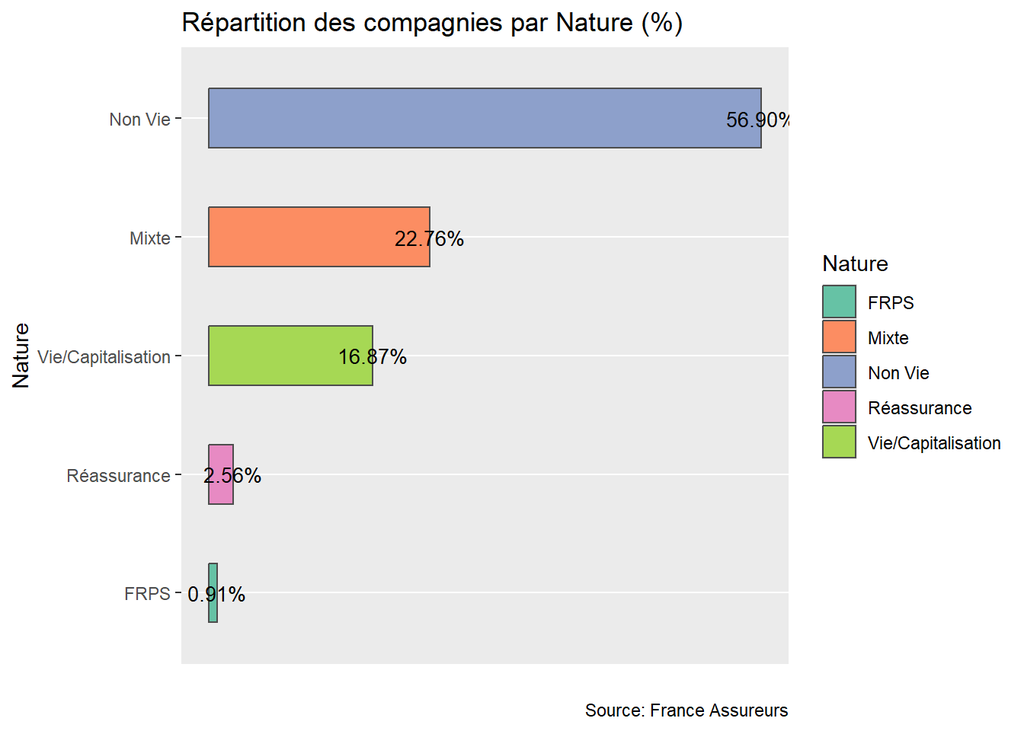

### 4.1.2 Répartition des compagnies par famille

La structure du marché est majoritairement dominée par les organismes mutualistes, lesquels représentent $53,71 \%$ de l’ensemble des compagnies. Le solde du marché se répartit de manière relativement équilibrée entre les assureurs traditionnels et les bancassureurs.

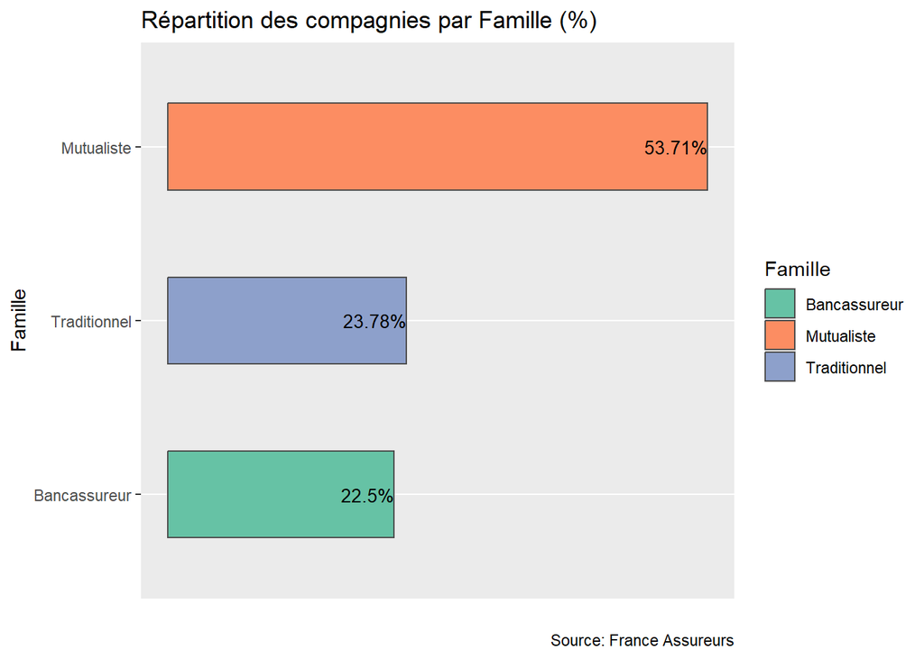

## 4.2 Analyse bivarariée

À l’exception du segment de la réassurance, les organismes mutualistes apparaissent comme majoritairement représentés dans l’ensemble des regroupements par nature d’activité. Leur part relative demeure plus élevée que celle des bancassureurs et des assureurs traditionnels, tant dans les catégories des prestataires d’assurance non-vie que dans celles de l’assurance vie et de la capitalisation. En revanche, le secteur de la réassurance est dominé par les assureurs traditionnels, lesquels représentent $71,7\%$ des acteurs recensés. Il convient également de souligner que seuls les organismes mutualistes et les assureurs traditionnels interviennent dans la fourniture de fonds de retraite et de prévoyance sociale (FRSP). Enfin, la répartition des différentes familles d’assureurs apparaît globalement équilibrée dans les activités mixtes combinant assurance vie et assurance non-vie.

Dans un soucis d’avoir des données de taille comparable entre les catégorie mixte, non-vie et vie, nous avons fusionné les catégories mixte et vie.

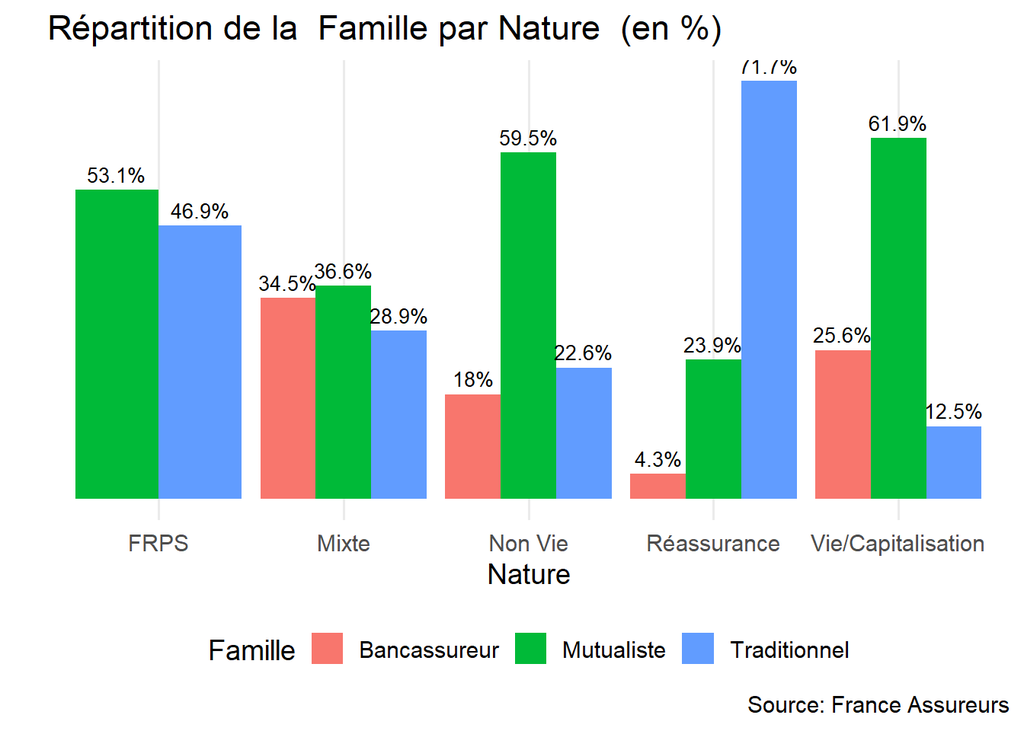

## 4.3 Analyses trimestrielles

Pour toutes les analyses qui suivent, nous ne prendrons en compte que deux natures de sociétés:

- Non Vie;
- Vie (regroupant les natures **Vie/Capitalisation** et **Mixte**).

La base de données contient 3444 trimestres avec des variables cibles déclarées. Nous pouvons donc observer l’évolution moyenne des Fonds propres et du ratio de solvabilité avec les données disponibles.

1. **Ratio de solvabilité**

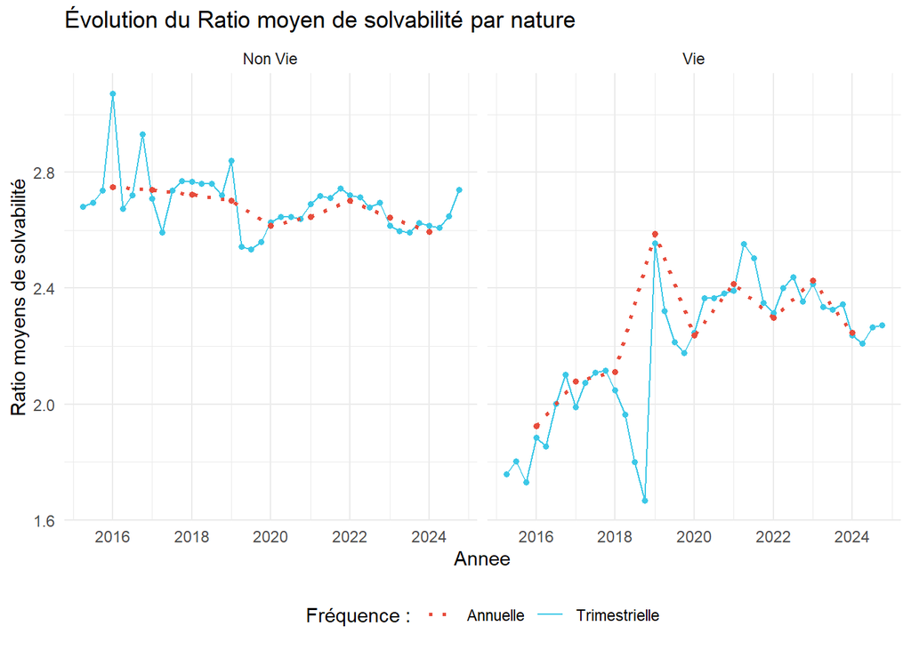

2. **Fonds Propres**

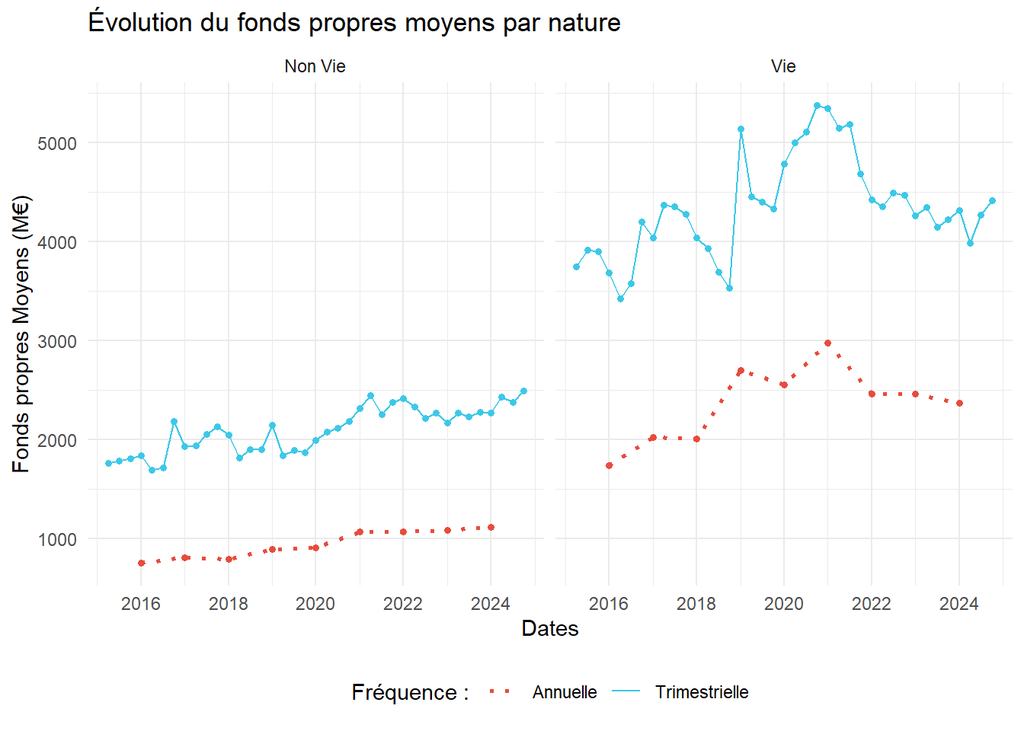

Les données trimestrielles offrent une vision plus détaillée de l’évolution des fonds propres. Ces graphiques montrent que les fonds propres des sociétés d’assurance Vie sont plus volatils que ceux des sociétés Non‑Vie. Par ailleurs, les fonds propres moyens des sociétés Vie et Non‑Vie semblent présenter une légère tendance haussière, ce qui suggère que les entreprises de notre échantillon accumulent progressivement davantage de fonds propres au fil du temps, malgré certaines fluctuations.

Nous observons également un écart important entre les valeurs annuelles et trimestrielles, aussi bien pour les sociétés d’assurance Non‑Vie que pour les sociétés Vie. Ce biais pourrait provenir de la taille des entreprises déclarant des données trimestrielles. En effet, toutes les sociétés ne transmettent pas d’informations trimestrielles. Seules 131 sociétés de la base disposent d’au moins une observation trimestrielle, ce qui représente environ 50.38$\%$ de l’ensemble des sociétés recensées.

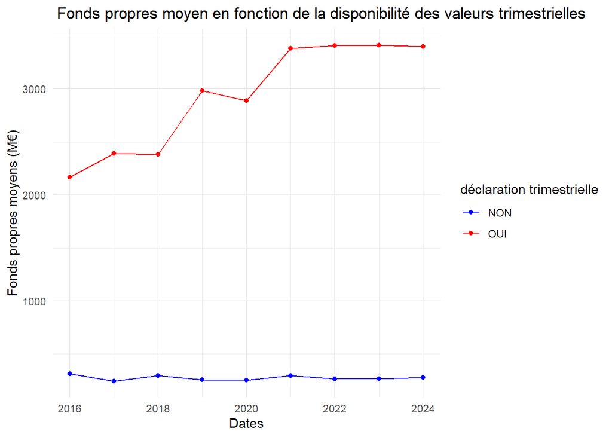

La divergence entre les moyennes annuelles et trimestrielles peut s’expliquer par le fait que les sociétés ne déclarant pas de données trimestrielles présentent, en moyenne, des niveaux de fonds propres annuels plus faibles. Autrement dit, seules les grandes sociétés d’assurance transmettent des données trimestrielles, tandis que toutes les sociétés — y compris les plus petites — déclarent des données annuelles. Ces petites sociétés tirent donc la moyenne annuelle globale vers le bas, ce qui crée un écart entre les deux séries.

Pour corriger ce biais de sélection présent dans les données trimestrielles, nous allons ajuster les séries trimestrielles à partir des données annuelles.

#### 4.3.0.1 Ajustement des valeurs trimestrielles

L’objectif est d’estimer le montant total de SCR et de fonds propres trimestriels que nous aurions obtenu si toutes les sociétés avaient transmis des valeurs trimestrielles. Pour cela, pour les sociétés ne déclarant que des valeurs annuelles, nous estimerons leurs valeurs trimestrielles en nous appuyant sur les comportements observés chez les sociétés qui déclarent à la fois des données trimestrielles et annuelles.

La méthode d’ajustement repose sur le calcul du taux de croissance moyen par nature, obtenu à partir des sociétés qui déclarent à la fois des valeurs annuelles et trimestrielles. Ces taux de croissance moyens servent ensuite à estimer les valeurs trimestrielles manquantes à partir des valeurs annuelles disponibles.

1. Pour le premier trimestre

Le taux de croissance moyen utilisé pour l’ajsutement correspond au taux de croissance entre la somme des valeurs de l’année précédente et la somme des valeurs du premier trimestre de l’année suivante.

**Supposons que nous souhaitons déterminer le taux de croissance moyen du premier trimestre de l’année t. Pour cela, nous considèrons l’ensemble E des sociétés ayant déclaré les valeurs de l’année t-1 ainsi que celles du premier trimestre de l’année t. Le taux de croissanse se calcul donc de la manière suivante :**

$$\tau_{moyen_{1,t}} = \frac{\sum_{j
\in E} SCR^j_{T_{1,t}}-\sum_{j \in E} SCR^j_{A_{t-1}} }{\sum_{j \in
E}SCR^j_{A_{t-1}}}$$
où :

- $SCR^j_{T_{1,t}}$ désigne le SCR de la société j au premier trimestre de l’année t;
- $SCR^j_{A_{t-1}}$ désigne le SCR de la société j de l’année t-1.

Nous faisons l’hypothèse que les sociétés n’ayant pas déclaré le premier trimestre de l’année t auraient connu un taux de croissance $\tau _{moyen_{1,t}}$ de leur SCR entre la fin de l’année t‑1 et le premier trimestre de l’année t. Nous estimons donc le SCR des sociétés n’ayant pas déclaré au premier trimestre de l’année t en multipliant la somme de leur SCR de l’année t‑1 par $1+\tau _{moyen_{1,t}}$. Pour estimer le SCR moyen au premier trimestre de l’année t, il suffit alors de considérer la somme des SCR des sociétés ayant déclaré, d’y ajouter la somme estimée pour celles qui n’ont pas déclaré, puis de diviser l’ensemble par le nombre total de sociétés.

2. Pour les autres trimestres (T2, T3 et T4)

Le taux de croissance moyen utilisé pour l’imputation correspond au taux de croissance entre la somme des valeurs du trimestre précédent et la somme des valeurs du trimestre que l’on souhaite estimer. Les valeurs estimer du premier trimestre servent à estimer ceux du deuxième, les valeurs de deuxième servent à estimer le troisième et les valeurs du troisième servent à estimer ceux du quatrième.

Supposons que nous souhaitons déterminer le taux de croissance moyen du trimestre i$\in \{2,3,4\}$ de l’année t. Pour cela, nous considèrons l’ensemble $E'$ des sociétés ayant déclaré les valeurs aux trimestres i-1 et i de l’année t. Le taux de croissanse se calcul donc de la manière suivante :

$$\tau_{moyen_{i,t}} = \frac{\sum_{j
\in E'} SCR^j_{T_{i,t}}-\sum_{j \in E'} SCR^j_{T_{i-1,t}}
}{\sum_{j \in E'}SCR^j_{T_{i-1,t}}}$$
Nous estimons le SCR des sociétés n’ayant pas déclaré au trimestre i de l’année t en multipliant l’estimation de leur SCR du trimestre i-1 de l’année t par $1+\tau _{moyen_{i,t}}$. Pour estimer le SCR moyen au trimestre i de l’année t, il suffit alors de considérer la somme des SCR des sociétés ayant déclaré, d’y ajouter la somme estimée pour celles qui n’ont pas déclaré, puis de diviser l’ensemble par le nombre total de sociétés.

### 4.3.1 Visualisation de l’ajustement

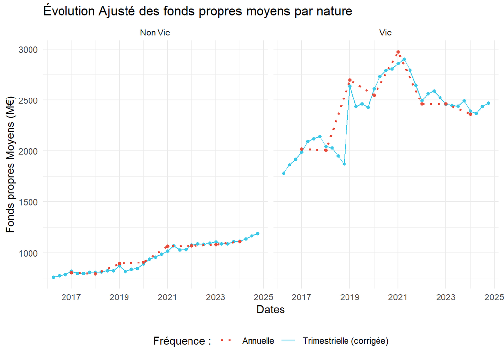

Après ajustement, on observe que les données trimestrielles s’alignent désormais mieux avec les données annuelles, ce qui confirme la correction du biais initialement identifié.

# 5 Modélisation

La complexité des interactions entre les variables macro-financières et la solvabilité des assureurs nécessite une approche empirique séquentielle. Notre stratégie de modélisation s’articule autour de trois axes complémentaires :

## 5.1 Régressions en différence

Les régressions en différence constituent étape d’analyse des liens de court terme entre les variables macro-financières et les indicateurs de solvabilité. Cette approche permet d’étudier la transmission immédiate des chocs macro-financiers tout en intégrant une dynamique autorégressive et d’éventuels effets retardés. Nous utilisons des modèles de régression linéaire estimés par les Moindres Carrés Ordinaires. La spécification générale du modèle est la suivante :

$$\begin{equation}
\Delta Y_t = \alpha + \sum_{i=1}^{n} \beta_i \Delta X_{i, t-k} + \rho
\Delta Y_{t-1} + \epsilon_t
\end{equation}$$

Ce modèle repose sur les hypothèses classiques des MCO : linéarité de la relation, exogénéité des régresseurs, homoscédasticité et absence d’autocorrélation des résidus, et normalité de la distribution des erreurs. Ces hypothèses sont vérifiées empiriquement en fin de partie à l’aide des tests appropriés.

### 5.1.1 Agrégation et transformation des données

Dans le cadre de cette modélisation, les données individuelles des assureurs et les variables macro-financières ont été agrégées par trimestre afin de ne conserver qu’une dimension temporelle. Cette agrégation permet d’obtenir une série synthétique reflétant l’évolution globale du secteur et de s’aligner sur les dates de reporting réglementaires du secteur. Ce choix méthodologique implique dans un premier temps de renoncer à l’analyse des effets individuels mais il est cohérent avec l’objectif de l’étude, centré sur la dynamique macroéconomique de la solvabilité.

Nous modéliserons les fonds propres, le SCR et le ratio de solvabilité des assureurs. Nous avons retenu les variables explicatives suivantes (valeurs trimestrielles) : les indices boursiers S&P 500 et Euro Stoxx 50, les taux d’intérêt de court et long terme, l’indice des prix à la consommation en France (IPC) et le Produit Intérieur Brut français.

### 5.1.2 Spécification des variables et stationnarité

Nous avons également enrichi nos données en calculant les différences logarithmiques des variables qui seront utilisées dans la régression en différence. Cette transformation permet de rendre les séries stationnaires et d’interpréter les variations comme des taux de croissance. Les taux d’intérêt sont quant à eux exprimés en différences premières, correspondant à des variations en niveau.

L’ensemble des variables sont transformées en différences logarithmiques selon $\Delta\ln(X_t) = \ln(X_t) - \ln(X_{t-1})$, à l’exception des taux d’intérêt exprimés en différences premières $\Delta X_t = X_t - X_{t-1}$, ces derniers pouvant prendre des valeurs négatives incompatibles avec le logarithme.

Si $t_{stat}$ < $t_{crit}$ : On rejette *H0* au seuil de significativité choisi.

### 5.1.3 Test de Causalité de Granger

Des tests de causalité au sens de Granger ont été réalisés afin d’identifier les retards pertinents des variables macro-financières dans les modèles dynamiques. Les tests ont été conduits sur des horizons allant de un à quatre trimestres afin de capturer d’éventuels délais de transmission. L’hypothèse nulle du test est la suivante :

*H0* : les coefficients associés aux valeurs retardées de la variable explicative sont conjointement nuls.

### 5.1.4 Estimation du modèle

Afin d’éviter les problèmes de multicolinéarité entre indices boursiers fortement corrélés, nous avons retenu uniquement le S&P 500 et l’Euro Stoxx. Ce choix permet de conserver une représentation pertinente des dynamiques des marchés, en combinant un indice global et un indice européen ce qui est cohérent avec l’exposition des assureurs étudiés.

#### 5.1.4.1 Spécifications

Des spécifications contemporaines ont d’abord été estimées par MCO (cf. Annexe Table). Malgré des diagnostics résiduels satisfaisants, les coefficients apparaissaient majoritairement non significatifs, suggérant l’existence de mécanismes de transmission retardés. Les modèles dynamiques finaux ont donc été construits en deux étapes : les tests de causalité de Granger ont d’abord permis d’identifier les retards pertinents puis les spécifications ont été comparées via les critères AIC et BIC afin d’assurer un équilibre entre robustesse statistique et interprétation économique.

Les résultats mettent en évidence des mécanismes de transmission différenciés entre branches Vie et Non-Vie ce qui est cohérent avec leurs structures d’activité respectives.

Les écarts-types des coefficients sont corrigés à l’aide de l’estimateur robuste de Newey-West afin de tenir compte d’une éventuelle hétéroscédasticité et autocorrélation des résidus. Bien que les tests de Breusch-Pagan et Ljung-Box ne rejettent pas formellement l’homoscédasticité et l’absence d’autocorrélation, la sensibilité des p-values à cette correction suggère la présence de déviations non détectées par ces tests sur petit échantillon, justifiant une approche robuste par précaution.

##### 5.1.4.1.1 Assureurs Vie

###### 5.1.4.1.1.1 Fonds propres - Vie

$$\begin{equation}
\begin{aligned}
\Delta \ln(\text{FP}_t) = \alpha & + \rho \Delta
\ln(\text{FP}_{t-1})
& + \beta_1 \Delta \text{TauxL}_{t-1}
& + \beta_2 \Delta \ln(\text{IPC})_{t-4}
& + \beta_3 \Delta \ln(\text{S\&P500})_{t-2} + \epsilon_t
\end{aligned}
\end{equation}$$

Analyse dynamique des Fonds Propres - Branche Vie

|  | Fonds Propres (Vie) Est. | Fonds Propres (Vie) t | Fonds Propres (Vie) p |
| --- | --- | --- | --- |
| (Intercept) | 0.0352 | 1.4257 | 0.1650 |
| dplyr = lag(diff_fonds_propres, 1) | −0.5197* | −2.6712 | 0.0124 |
| dplyr = lag(diff_taux_long, 1) | −0.0901** | −3.1146 | 0.0042 |
| dplyr = lag(rendement_sp500, 2) | 0.3673** | 3.0802 | 0.0046 |
| dplyr = lag(diff_ipc, 4) | −4.4542* | −2.5296 | 0.0173 |
| Num.Obs. | 33 |  |  |
| R2 | 0.390 |  |  |
| R2 Adj. | 0.303 |  |  |

###### 5.1.4.1.1.2 SCR - Vie

$$\begin{equation}
\begin{aligned}
\Delta \ln(\text{SCR}_t) = \alpha & + \rho \Delta
\ln(\text{SCR}_{t-1})
& + \beta_1 \Delta \text{TauxL}_{t-1}
& + \beta_2 \Delta \ln(\text{IPC})_{t-3} + \epsilon_t
\end{aligned}
\end{equation}$$

Analyse dynamique du SCR - Branche Vie

|  | SCR (Vie) Est. | SCR (Vie) t | SCR (Vie) p |
| --- | --- | --- | --- |
| (Intercept) | 0.0388** | 2.9627 | 0.0058 |
| dplyr = lag(diff_scr, 1) | −0.4102** | −2.7535 | 0.0098 |
| dplyr = lag(diff_taux_long, 1) | −0.0873** | −2.9415 | 0.0061 |
| dplyr = lag(diff_ipc, 3) | −4.0140** | −3.3197 | 0.0023 |
| Num.Obs. | 35 |  |  |
| R2 | 0.352 |  |  |
| R2 Adj. | 0.289 |  |  |

Les résultats montrent que le SCR des assureurs Vie présente une dynamique de rappel importante comme l’indique la significativité du terme autorégressif. Les ajustements du besoin en capitals sont donc progressifs et les chocs observés sur le SCR tendant à se résorber partiellement au trimestre suivant. Les taux d’intérêt de long terme et l’inflation exercent tous deux un effet négatif sur la croissance du SCR. Ces résultats apparaissent cohérents dans la mesure où ces deux variables influencent les mécanismes d’actualisation des engagements des assureurs. Dans un contexte de hausse des taux, souvent associé à des tensions inflationnistes, la valeur actuelle des passifs futurs diminue, ce qui contribue à alléger les exigences réglementaires en capital. L’effet retardé de l’IPC suggère toutefois que cette transmission s’opère progressivement dans le bilan des assureurs Vie. Par ailleurs, la constante positive et significative indique l’existence d’une croissance résiduelle du SCR non entièrement expliquée par les variables macro-financières intégrées au modèle.

###### 5.1.4.1.1.3 Ratio de solvabilité - Vie

$$\begin{equation}
\begin{aligned}
\Delta \ln(\text{Ratio\_Moyen}_t) = \alpha & + \rho \Delta
\ln(\text{Ratio\_Moyen}_{t-1})
& + \beta_1 \Delta \ln(\text{S\&P500})_{t-3} + \epsilon_t
\end{aligned}
\end{equation}$$

Analyse dynamique du ratio de solvabilité - Branche Vie

|  | Ratio (Vie) Est. | Ratio (Vie) t | Ratio (Vie) p |
| --- | --- | --- | --- |
| (Intercept) | −0.0130 | −1.3896 | 0.1742 |
| dplyr = lag(diff_ratio, 1) | −0.4683*** | −4.3912 | 0.0001 |
| dplyr = lag(rendement_sp500, 3) | 0.2843+ | 1.7086 | 0.0972 |
| Num.Obs. | 35 |  |  |
| R2 | 0.307 |  |  |
| R2 Adj. | 0.263 |  |  |

La dynamique du ratio de solvabilité semble principalement expliquée par son propre terme retardé dont le coefficient négatif traduit un mécanisme de retour à la moyenne dans l’ajustement de la solvabilité des assureurs Vie. Le rendement du S&P500 exerce un effet positif modéré sur le ratio de solvabilité avec un retard de trois trimestres, suggérant qu’un environnement boursier favorable améliore progressivement la solvabilité des assureurs Vie à travers la valorisation des actifs financiers et de meilleures conditions de rendement des placements. L’absence d’effet significatif sur le SCR suggère que cette amélioration des fonds propres ne semble pas être entièrement compensée par une hausse des exigences en capital. À l’inverse, les variables de taux d’intérêt et d’inflation n’apparaissent plus comme des déterminants robustes des variations du ratio de solvabilité probablement en raison d’effets compensatoires entre fonds propres et SCR. Par ailleurs, la constante n’apparaît plus significative, il ne semble pas y avoir de croissance structurelle du ratio non expliquée par les variables macro-financières et la dynamique de rappel.

##### 5.1.4.1.2 Assureurs Non-Vie

Nous adoptons la même démarche pour les assureurs Non-Vie malgré l’absence de résultats forts aux tests de Granger.

###### 5.1.4.1.2.1 Fonds Propres - Non-Vie

$$\begin{equation}
\begin{aligned}
\Delta \ln(\text{FP}_t) = \alpha & + \rho \Delta
\ln(\text{FP}_{t-1})
& + \beta_1 \Delta \ln(\text{IPC})_{t-3}
& + \beta_2 \Delta \text{TauxC}_{t-3}
& + \beta_3 \Delta \text{TauxL}_{t-3} + \epsilon_t
\end{aligned}
\end{equation}$$

Analyse dynamique des Fonds Propres - Branche Non-Vie

|  | Fonds Propres (Non-Vie) Est. | Fonds Propres (Non-Vie) t | Fonds Propres (Non-Vie) p |
| --- | --- | --- | --- |
| (Intercept) | 0.0367** | 3.5278 | 0.0014 |
| dplyr = lag(diff_fonds_propres, 1) | −0.4123*** | −4.9547 | &lt;1e−04 |
| dplyr = lag(diff_ipc, 3) | −4.1880* | −2.3698 | 0.0244 |
| dplyr = lag(diff_taux_court, 3) | −0.0332 | −1.4900 | 0.1467 |
| dplyr = lag(diff_taux_long, 3) | 0.0762* | 2.1063 | 0.0436 |
| Num.Obs. | 35 |  |  |
| R2 | 0.366 |  |  |
| R2 Adj. | 0.281 |  |  |

###### 5.1.4.1.2.2 SCR - Non-Vie

$$\begin{equation}
\begin{aligned}
\Delta \ln(\text{SCR}_t) = \alpha & + \rho \Delta
\ln(\text{SCR}_{t-1})
& + \beta_1 \Delta \text{TauxC}_{t-3} + \epsilon_t
\end{aligned}
\end{equation}$$

Analyse dynamique du SCR - Branche Non-Vie

|  | SCR (Non-Vie) Est. | SCR (Non-Vie) t | SCR (Non-Vie) p |
| --- | --- | --- | --- |
| (Intercept) | 0.0177* | 2.2132 | 0.0341 |
| dplyr = lag(diff_scr, 1) | −0.3273*** | −4.2606 | 0.0002 |
| dplyr = lag(diff_taux_court, 3) | −0.0233** | −3.0898 | 0.0041 |
| Num.Obs. | 35 |  |  |
| R2 | 0.154 |  |  |
| R2 Adj. | 0.101 |  |  |

Les résultats montrent également qu’une hausse des taux d’intérêt de court terme réduit la croissance du SCR avec un retard de trois trimestres. Ce résultat suggère une transmission différée des conditions de taux aux exigences réglementaires en capital, possiblement via les mécanismes d’actualisation des engagements et l’évolution de l’exposition au risque de taux. La constante positive suggère une dynamique de croissance structurelle interne peu sensible aux chocs macro-financiers immédiats.

###### 5.1.4.1.2.3 Ratio de solvabilité - Non-Vie

$$\begin{equation}
\begin{aligned}
\Delta \ln(\text{Ratio\_Moyen}_t) = \alpha & + \rho \Delta
\ln(\text{Ratio\_Moyen}_{t-1})
& + \beta_1 \Delta \text{TauxL}_{t-3} & + \beta_2 \Delta
\text{TauxC}_{t-3} + \epsilon_t
\end{aligned}
\end{equation}$$

Analyse dynamique du ratio de solvabilité - Branche Non-Vie

|  | Ratio (Non-Vie) Est. | Ratio (Non-Vie) t | Ratio (Non-Vie) p |
| --- | --- | --- | --- |
| (Intercept) | −0.0046+ | −1.7371 | 0.0923 |
| dplyr = lag(diff_ratio, 1) | −0.3611*** | −8.8205 | &lt;1e−04 |
| dplyr = lag(diff_taux_court, 3) | −0.0273*** | −6.4019 | &lt;1e−04 |
| dplyr = lag(diff_taux_long, 3) | 0.0407** | 3.1076 | 0.0040 |
| Num.Obs. | 35 |  |  |
| R2 | 0.253 |  |  |
| R2 Adj. | 0.180 |  |  |

Une hausse des taux d’intérêt de long terme améliore le ratio de solvabilité avec un retard de trois trimestres, probablement via l’augmentation des fonds propres et l’amélioration des revenus financiers. À l’inverse, les taux courts exercent un effet négatif sur le ratio de solvabilité. Ce résultat suggère qu’un relèvement des taux courts peut temporairement détériorer l’équilibre prudentiel des assureurs Non-Vie.

#### 5.1.4.2 Diagnostics et limites du modèle

Ces résultats doivent être interprétés avec prudence en raison de plusieurs limites économétriques. La taille réduite de l’échantillon restreint la puissance statistique des estimations. L’ensemble des modèles estimés satisfont les conditions de validité économétrique : les tests de Jarque-Bera, Breusch-Pagan et Ljung-Box ne rejettent pas la normalité des résidus, l’homoscédasticité et l’absence d’autocorrélation (cf. Annexe Tables). Néanmoins, compte tenu de la faible puissance de ces tests sur petit échantillon et de la sensibilité des p-values à la correction, l’estimateur de Newey-West a été appliqué à l’ensemble des modèles afin de garantir la robustesse des inférences. Par ailleurs, un biais d’endogénéité lié à l’omission de variables pertinentes ne peut être exclu. Les variables macro-financières retenues sont susceptibles d’être corrélées avec d’autres déterminants de la solvabilité non intégrés au modèle ce qui limite la validité de cette modélisation.

Par ailleurs, cette approche en différences ne permet pas d’identifier les relations d’équilibre de long terme. Ces éléments justifient le recours à une spécification ARDL qui permet d’intégrer simultanément dynamiques de court terme et relations de cointégration éventuelles.

## 5.2 Modèle ARDL

Le modèle ARDL (Autoregressive Distributed Lag) est une approche économétrique puissante pour examiner les liens dynamiques entre des variables dans le temps. Contrairement aux méthodes classiques de cointégration, l’ARDL est particulièrement flexible car il permet d’analyser des séries ayant différents ordres d’intégration ($I(0)$ ou $I(1)$)

### 5.2.1 Formulation Mathématique du Modèle

Le modèle fusionne une partie autorégressive (les valeurs passées du ratio) et des délais répartis (les valeurs actuelles et passées des marchés).L’équation structurelle est la suivante:

$$ratio_{t} = \phi + \sum_{i=1}^{p} a_{i}
ratio_{t-i} + \sum_{j=0}^{q} b_{j} X_{t-j} + \epsilon_{t}$$

Où :

- $ratio_{t}$ : La variable dépendante.
- $X_{t}$ : Les variables explicatives.
- $p, q$ : Les ordres de retard respectifs.
- $\epsilon_{t}$ : Le terme d’erreur (bruit blanc)

Pour estimer notre modèle nous procedons en 3 étapes :

1. Variables explicatives et Stationnarité.
2. Recherche des retard optimaux et estimation du modèle
3. Diagnostic du modèle

### 5.2.2 Variables explicatives et Stationnarité

Pour ce modèle, les variables explicatives retenues se divisent en deux catégories :

- Les variables de marché : les indices boursiers S&P 500 et CAC 40.
- Les variables macroéconomiques : le taux de croissance du PIB, l’Indice des Prix à la Consommation (IPC) et le taux d’intérêt de long terme.

Afin de traiter les séries présentant une croissance de nature exponentielle, nous avons appliqué une transformation logarithmique aux indices boursiers (CAC 40, S&P 500) ainsi qu’à l’IPC. Cette pratique, standard en économétrie financière, répond à un objectif analytique majeur : elle permet de linéariser ces séries et de convertir les variations absolues en variations relatives. Ainsi, les coefficients estimés du modèle s’interpréteront directement comme des élasticités, mesurant l’impact d’une variation de $1 \%$ d’un indice de marché ou des prix sur le ratio de solvabilité.

Comme souligné précédemment, la validité du test de cointégration aux bornes de l’approche ARDL repose sur l’hypothèse stricte qu’aucune série n’est intégrée d’ordre 2, soit $I(2)$, ou supérieur, ce qui rendrait la méthode caduque. L’évaluation de l’ordre d’intégration de chaque variable a donc été menée rigoureusement en suivant la procédure séquentielle du test de Dickey-Fuller Augmenté (ADF) et du test de KPSS, avec une méthodologie identique à celle détaillée dans la section précédente.

À l’issue de ces tests de racine unitaire, les résultats suivants se dégagent :

- Variables $I(0)$ : Le ratio de solvabilité et le taux de croissance du PIB sont stationnaires en niveau.
- Variables $I(1)$ : Les logarithmes des variables de marché (CAC 40, S&P 500) et de l’inflation (IPC) présentent une racine unitaire en niveau, mais deviennent stationnaires après un passage en différence première.
- Traitement de la variable $I(2)$ : Le test a révélé que le taux d’intérêt de long terme est intégré d’ordre 2. Pour l’introduire de manière valide dans le modèle sans violer les hypothèses de l’ARDL, cette série a été préalablement différenciée une fois. La série résultante (la variation du taux d’intérêt) est alors $I(1)$.

Cette coexistence de variables explicatives intégrées d’ordres mixtes, $I(0)$ et $I(1)$, justifie pleinement le recours et la pertinence de la modélisation ARDL pour notre étude.

### 5.2.3 Recherche des retard optimaux et estimation du modèle

#### 5.2.3.1 Retards optimaux

Retards optimaux sélectionnés

| ratio | l_ipc | taux_pib | d_taux_l | l_sp | l_cac |
| --- | --- | --- | --- | --- | --- |
| 2 | 3 | 0 | 1 | 0 | 0 |

Afin d’optimiser la précision de l’estimation, le nombre idéal de retards a été fixé automatiquement en s’appuyant sur des critères d’information. Notre choix s’est spécifiquement porté sur le critère de Schwarz, ou critère d’information bayésien (BIC). Contrairement au critère d’Akaike (AIC), le BIC pénalise plus fortement la complexité du modèle (le nombre de paramètres estimés), ce qui permet de privilégier une spécification plus stricte et parcimonieuse, limitant ainsi le risque de surapprentissage.

L’algorithme d’optimisation a convergé vers la structure optimale suivante : un modèle $\text{ARDL}(2, 3, 0, 1, 0, 0)$. L’équation correspondante peut se formaliser ainsi :

$$\begin{aligned}
\text{ratio}_t = \alpha_0 & + \gamma_1 \text{ratio}_{t-1} + \gamma_2
\text{ratio}_{t-2} \\
& + \beta_{1,0} l\_ipc_t + \beta_{1,1} l\_ipc_{t-1} + \beta_{1,2}
l\_ipc_{t-2} + \beta_{1,3} l\_ipc_{t-3} \\
& + \beta_{2,0} \text{taux\_pib}_t + \beta_{3,0} d\_taux\_l_t +
\beta_{3,1} d\_taux\_l_{t-1} \\
& + \beta_{4,0} l\_sp_t + \beta_{5,0} l\_cac_t + \epsilon_t
\end{aligned}$$

#### 5.2.3.2 Test des bornes (cointégration)

```
    Bounds F-test (Wald) for no cointegration

data:  d(ratio) ~ L(ratio, 1) + L(l_ipc, 1) + taux_pib + L(d_taux_l,     1) + l_sp + l_cac + d(L(ratio, 1)) + d(l_ipc) + d(L(l_ipc,     1)) + d(L(l_ipc, 2)) + d(d_taux_l)
F = 8.0944, p-value = 1e-06
alternative hypothesis: Possible cointegration
null values:
   k    T
   5 1000
```

**Interprétation des résultats : Cointégration**

La première étape de l’analyse consiste à vérifier l’existence d’une relation d’équilibre de long terme entre le ratio de solvabilité et ses déterminants via le test aux bornes (Bounds F-test). La statistique de Fisher obtenue est de 8.09 avec une p-value de 0. Ce résultat, largement inférieur au seuil de $5 \%$, nous permet de rejeter l’hypothèse nulle d’absence de cointégration. Il existe donc une relation stable et non fallacieuse entre ces variables sur le long terme, ce qui valide l’utilisation du modèle ARDL pour analyser la dynamique du ratio.

#### 5.2.3.3 Coefficients de long terme

```
         Term    Estimate Std. Error   t value     Pr(>|t|)
1 (Intercept)  4.17083425 1.14619512  3.638852 0.0016339399
2       l_ipc -0.49536062 0.38120351 -1.299465 0.2085644204
3    taux_pib -0.41451004 0.28801957 -1.439173 0.1655694822
4    d_taux_l  0.07817369 0.04483171  1.743714 0.0965614870
5        l_sp  0.45504111 0.11565555  3.934451 0.0008200249
6       l_cac -0.38493608 0.17086842 -2.252822 0.0356567527
```

**Interprétation des résultats : Relation de Long Terme**

log(IPC) et Taux PIB sont non significativent. Cela indiquent que ces variables macroéconomiques n’exercent pas d’influence statistiquement détectable sur le ratio de solvabilité à long terme, une fois les effets de marché contrôlés.

Le ratio de solvabilité des sociétés d’assurances est structurellement lié aux dynamiques des marchés actions. La diversification géographique apparaît comme un facteur clé : l’exposition au marché américain renforce la solvabilité, tandis qu’une concentration sur le marché européen constitue un facteur de vulnérabilité. Ce résultat plaide pour une gestion prudentielle attentive à la composition géographique des portefeuilles.

#### 5.2.3.4 Dynamique de court terme

Pour estimer la dynamique de court terme, on réecrit le modèle sous la forme de correction d’erreur. L’estimation du modèle sous sa forme non contrainte à correction d’erreur permet d’analyser la vitesse à laquelle le ratio de solvabilité s’ajuste après un choc exogène. Il s’agit d’un transformation algébrique de l’équation de base du modèle :

$$\begin{aligned}
\Delta \text{ratio}_t = \alpha_0 &+ \underbrace{\lambda \cdot \left[
\text{ratio}_{t-1} - \left( \beta_1 l\_ipc_{t-1} + \beta_2
\text{taux\_pib}_{t-1} + \beta_3 d\_taux\_l_{t-1} + \beta_4 l\_sp_{t-1}
+ \beta_5 l\_cac_{t-1} \right) \right]}_{\textbf{Force de Rappel
(ECT}_{t-1}\textbf{)}} \\
&+ \gamma_{1} \Delta \text{ratio}_{t-1} \\
&+ \delta_{1,0} \Delta l\_ipc_t + \delta_{1,1} \Delta l\_ipc_{t-1} +
\delta_{1,2} \Delta l\_ipc_{t-2} \\
&+ \delta_{3,0} \Delta d\_taux\_l_t + \epsilon_t
\end{aligned}$$

$\lambda$ est le coefficient d’ajustement : correspond au coefficient du Terme de Correction d’Erreur (ECT). Dans un modèle de cointégration, elle mesure la capacité de la variable dépendante (le ratio de solvabilité) à retourner vers son équilibre de long terme après un choc macroéconomique.D’un point de vue mathématique, elle indique quelle proportion de l’écart à l’équilibre constaté à la période $t-1$ est résorbée à la période $t$.

Ce coefficient est estimé à $\lambda = −1.44 \;(p < 0.001)$, étant significatif au seuil de 1%. La négativité du coefficient confirme l’existence d’une relation de cointégration entre le ratio de solvabilité et les variables macroéconomiques.La valeur absolue supérieure à l’unité traduit une dynamique de convergence oscillatoire : le système sur-corrige les écarts à l’équilibre d’un trimestre à l’autre. Ce résultat est cohérent avec la forte volatilité observée sur le graphique du ratio, notamment lors de la période 2019-2022, où les mesures de sauvegarde et la reprise des marchés ont provoqué des ajustements brutaux et rapides de la solvabilité globale du marché.

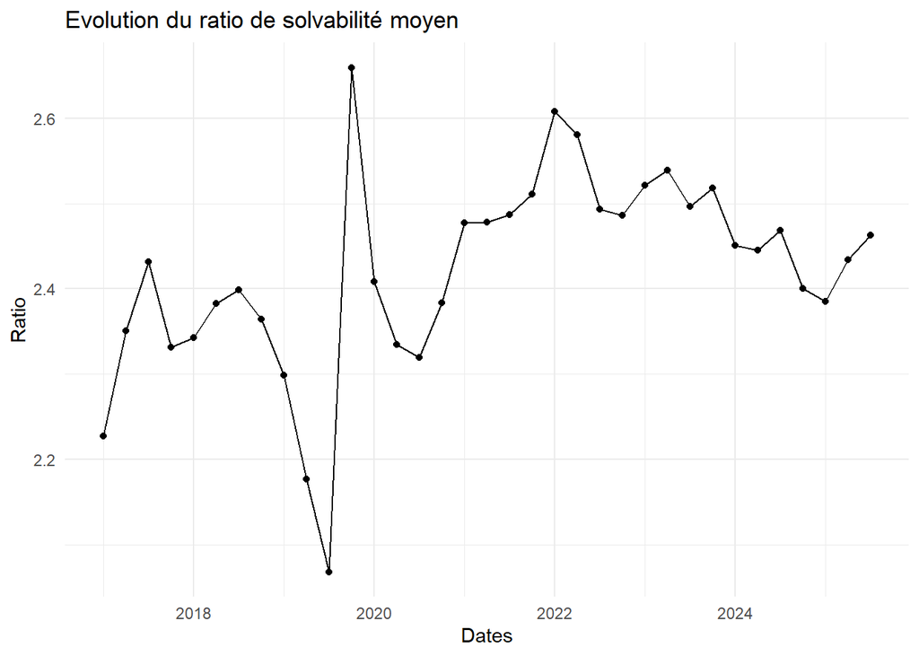

#### 5.2.3.5 Diagnostic et limites du modèle

1. Diagnostic des résidus

La validité des inférences statistiques repose sur le respect des hypothèses fondamentales du modèle de régression. Trois batteries de tests ont été conduites pour vérifier la qualité des résidus.

Test d’autocorrélation (Breusch-Godfrey) : la statistique LM = 9.47 associée à une p-value de 0.050 ne permet pas de rejeter l’hypothèse nulle d’absence d’autocorrélation au seuil de 5%. La structure de retards retenue capture donc correctement la dynamique temporelle des données, garantissant la validité des écarts-types estimés.

Test de normalité (Jarque-Bera) : la statistique χ² = 2.04 (p-value = 0.36) conduit au non-rejet de l’hypothèse de normalité des résidus. Ce résultat assure la validité des tests de Student et de Fisher, même sur un échantillon de taille modeste.

Tests de stabilité structurelle (CUSUM et CUSUM²) : les sommes cumulées des résidus récursifs demeurent à l’intérieur des bandes de confiance à 5% sur l’ensemble de la période d’estimation. Les coefficients du modèle sont donc stables dans le temps, confirmant l’absence de rupture structurelle.

2. Limites du modèles

Malgré la robustesse des diagnostics, plusieurs limites méthodologiques doivent être soulignées.

1. Contrainte d’échantillon : avec seulement 35 observations trimestrielles, le modèle souffre d’une faible puissance statistique. Cette taille limite le nombre de variables explicatives et de retards pouvant être introduits sans surparamétrage
2. Agrégation sectorielle : l’utilisation d’un ratio de solvabilité moyen masque l’hétérogénéité des institutions. Les dynamiques d’ajustement peuvent différer significativement entre assureurs, banques et autres acteurs financiers.
3. Période d’estimation atypique : l’échantillon inclut des épisodes de stress majeurs (crise Covid-19, choc inflationniste 2022-2023) qui peuvent influencer de manière disproportionnée les coefficients estimés. La généralisation des résultats à des périodes plus stables requiert une certaine prudence.

# 6 Conclusion

Cette étude démontre que la solvabilité des assureurs n’est pas une donnée statique, mais le produit de dynamiques complexes et différenciées selon les segments de marché. Nos résultats soulignent une hétérogénéité marquée dans la spécificité des métiers : tandis que les assureurs Vie voient leur solidité financière portée par la performance des marchés actions, notamment le S&P 500, les assureurs Non-Vie affichent une vulnérabilité plus prononcée aux fluctuations des taux d’intérêt. Cette sensibilité sectorielle s’inscrit par ailleurs dans une dynamique de marchés globaux où la diversification géographique joue un rôle protecteur prépondérant. L’analyse ARDL met ainsi en lumière que l’exposition au marché américain renforce la solvabilité, là où une concentration sur le marché européen peut constituer un facteur de fragilité. Enfin, bien que la mise en évidence d’une relation de cointégration confirme une stabilité sous tension avec une convergence de long terme, la trajectoire du ratio reste marquée par des oscillations trimestrielles dues à une sur-correction des chocs macroéconomiques. Si ces mécanismes de rappel interne assurent une certaine résilience au secteur, la dépendance aux variables financières demeure majeure. Ces conclusions plaident donc, tant pour les régulateurs que pour les directions financières, en faveur d’une gestion proactive de l’allocation d’actifs et d’une surveillance accrue des cycles de taux, garantissant que la promesse d’indemnisation initiale soit honorée en dépit de la volatilité des marchés.

# 7 Annexes

## 7.1 Analyse descriptive

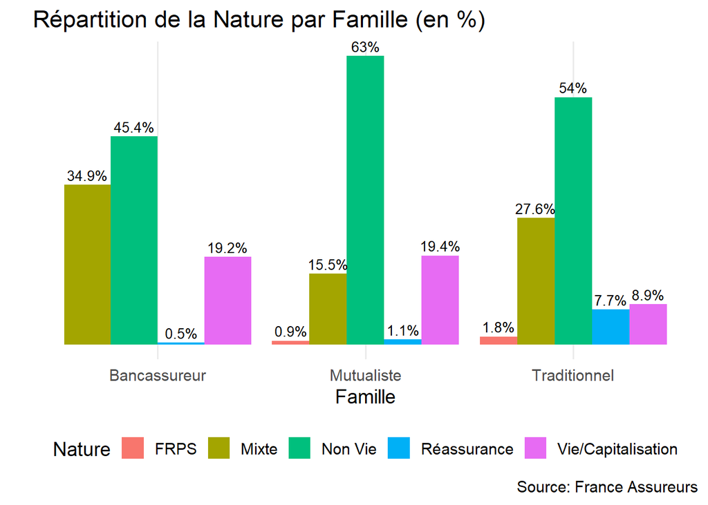

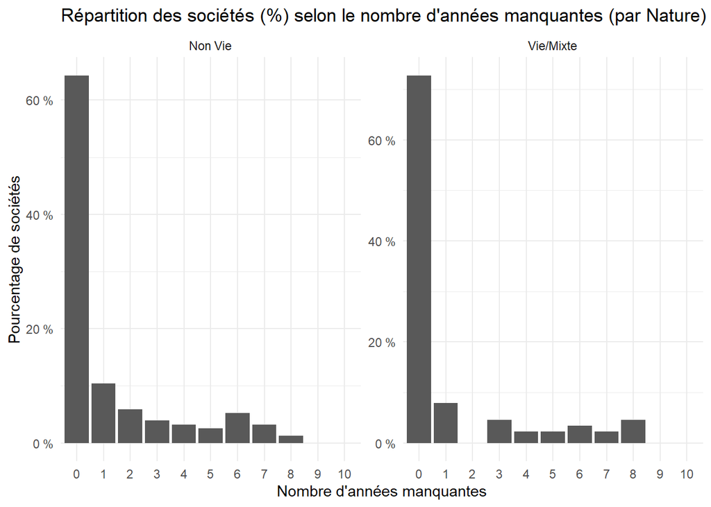

### 7.1.1 Les indices boursiers.

#### 7.1.1.1 L’EURO STOXX 50

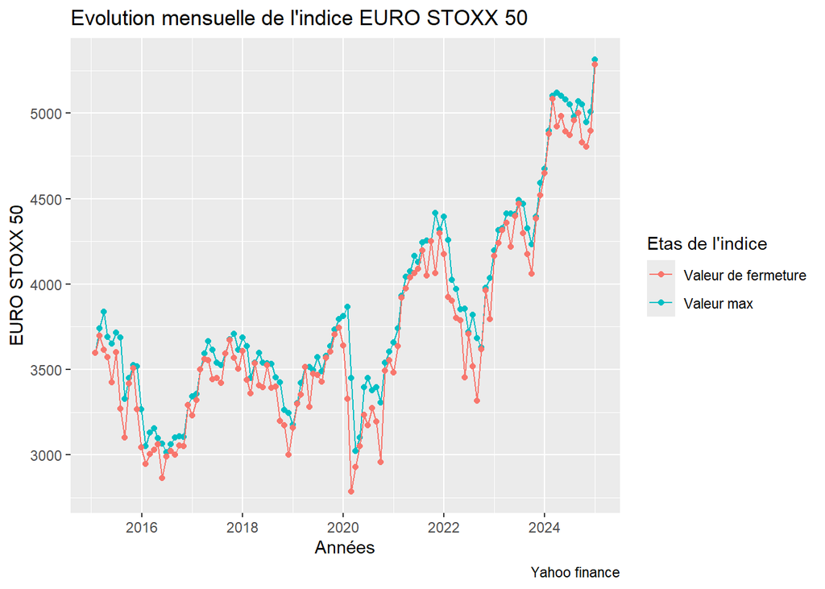

Ces indices évoluent de manière globalement parallèle, suivant une tendance générale à la hausse. Néanmoins, une chute marquée est observée en mars 2020, atteignant un niveau minimal, en raison des mesures de restriction et de l’incertitude économique engendrées par la pandémie de COVID-19. C’est en effet en cette période que Donald Trump avait annoncé la restriction des entrées sur le téritoire américain; source d’une panique boursière.

#### 7.1.1.2 Le Standard & Poor’s 500 (S&P 500)

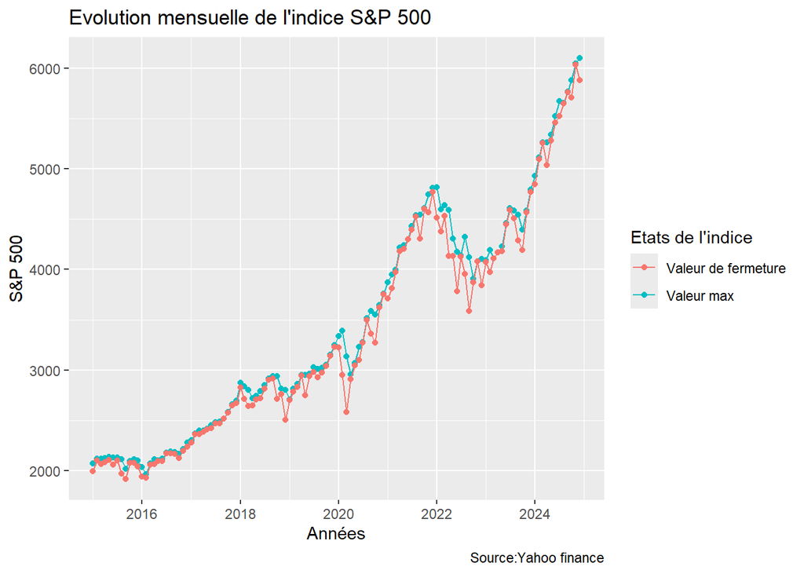

Le S&P 500 connaît une tendence croissance sur toute la période avec également une pertubation en mars 2020 due à la pandémie de OVID-19. Toutefois cette indice est visiblement moins volatile que l’EURO STOXX 50.

#### 7.1.1.3 L’indice CAC 40

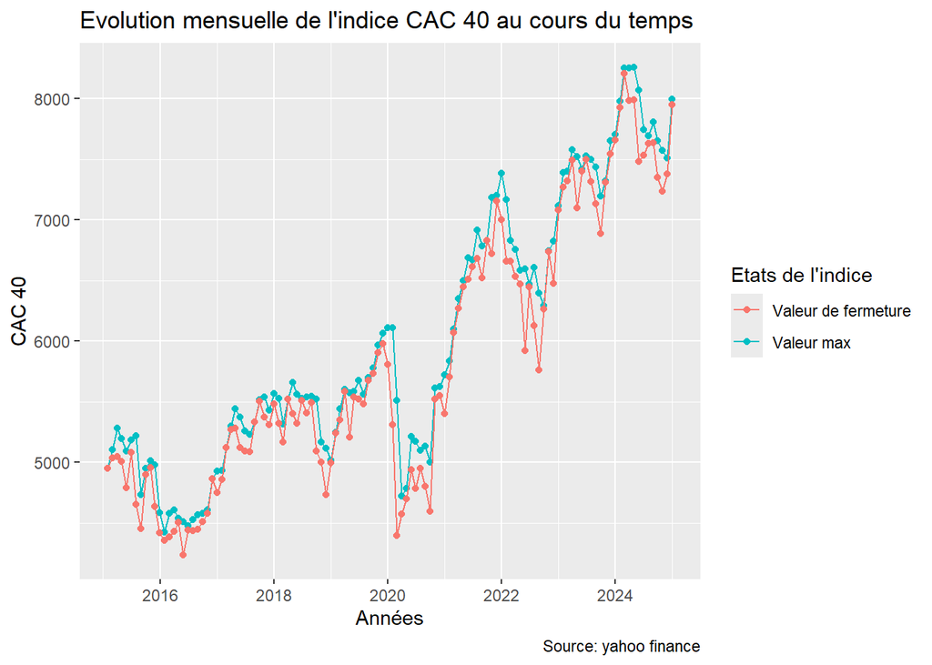

Comme pour l’EURO STOXX, les valeurs de l’indice CAC 40 évoluent de manière parallèle et croissante avec également une chutte marqué en mars 2020 pour la même raison que précédemment.

#### 7.1.1.4 L’indice DAX

Le DAX (Deutscher Aktienindex) est l’indice de référence du marché boursier allemand, regroupant les 40 principales sociétés cotées à la Bourse de Francfort, sélectionnées principalement en fonction de leur capitalisation boursière flottante. C’est l’équivalent allemend du CAC 40. Le graphique ci-après représente les variation de cet indice sur la période $2015-2025.$

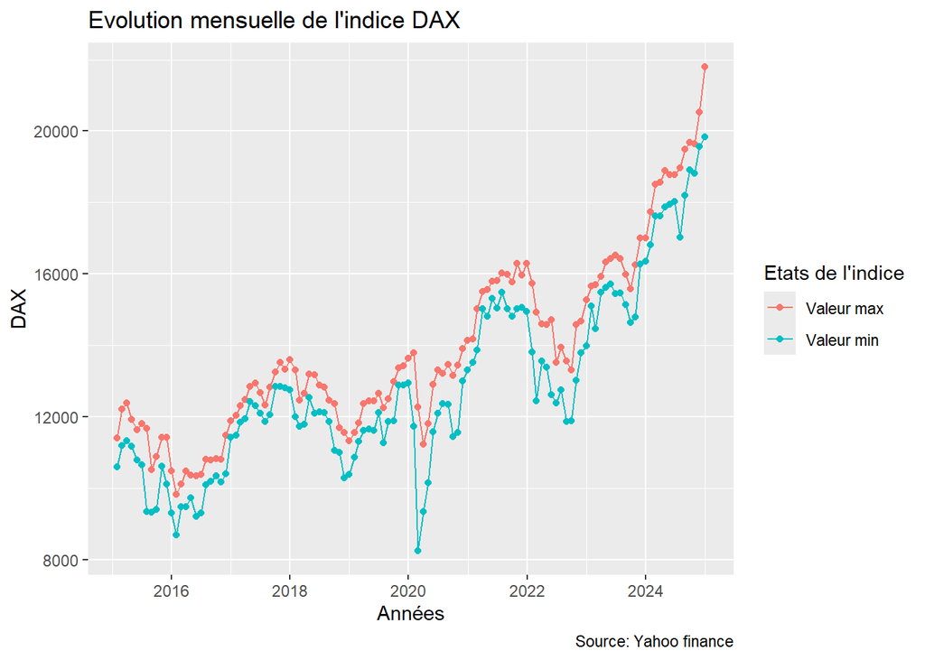

## 7.2 Modélisation

### 7.2.1 Régression en différence

Résultats de la régression du ratio de solvabilité - Vie

|  | (1) Est. | (1) S.E. | (1) t | (1) p |
| --- | --- | --- | --- | --- |
| (Intercept) | −0.0158 | 0.0205 | −0.7704 | 0.4475 |
| rendement_stoxx | 0.1268 | 0.2570 | 0.4936 | 0.6255 |
| rendement_sp500 | 0.2066 | 0.2412 | 0.8566 | 0.3989 |
| diff_ipc | 0.6865 | 2.6065 | 0.2634 | 0.7942 |
| diff_taux_court | −0.0432 | 0.0382 | −1.1325 | 0.2670 |
| diff_taux_long | 0.0599 | 0.0455 | 1.3172 | 0.1984 |
| diff_pib | 0.2577 | 0.4199 | 0.6138 | 0.5443 |
| Num.Obs. | 35 |  |  |  |
| R2 | 0.176 |  |  |  |
| R2 Adj. | −0.000 |  |  |  |

Tests sur les résidus modèle ratio - Vie

|  | Test | Statistique | P_value | Verdict |
| --- | --- | --- | --- | --- |
| DW | Autocorrélation (Durbin-Watson) | 2.6972 | 0.9789 | Hypothèse validée |
| X-squared | Indépendance Globale (Ljung-Box) | 17.6091 | 0.0619 | Bruit blanc confirmé |
| BP | Homoscédasticité (Breusch-Pagan) | 4.5900 | 0.5974 | Hypothèse validée |
| W | Normalité (Shapiro-Wilk) | 0.9649 | 0.3184 | Hypothèse validée |

Tests diagnostiques - Fonds Propres Vie

| Test | Statistique | p.value | Hypothèse_nulle |
| --- | --- | --- | --- |
| Ljung-Box | 0.0971 | 0.7554 | Pas d’autocorrélation |
| Jarque-Bera | 0.1760 | 0.9158 | Normalité des résidus |
| Breusch-Pagan | 1.7255 | 0.7861 | Homoscédasticité |

Facteurs d’inflation de la variance (VIF) - Fonds Propres Vie

|  | Variable | VIF |
| --- | --- | --- |
| dplyr::lag(diff_fonds_propres, 1) | dplyr::lag(diff_fonds_propres, 1) | 1.309 |
| dplyr::lag(diff_taux_long, 1) | dplyr::lag(diff_taux_long, 1) | 1.051 |
| dplyr::lag(rendement_sp500, 2) | dplyr::lag(rendement_sp500, 2) | 1.068 |
| dplyr::lag(diff_ipc, 4) | dplyr::lag(diff_ipc, 4) | 1.281 |

Tests diagnostiques - SCR Vie

[output not shown]

Facteurs d’inflation de la variance (VIF) - SCR Vie

|  | Variable | VIF |
| --- | --- | --- |
| dplyr::lag(diff_scr, 1) | dplyr::lag(diff_scr, 1) | 1.054 |
| dplyr::lag(diff_taux_long, 1) | dplyr::lag(diff_taux_long, 1) | 1.212 |
| dplyr::lag(diff_ipc, 3) | dplyr::lag(diff_ipc, 3) | 1.243 |

Tests diagnostiques - Ratio de solvabilité Vie

| Test | Statistique | p.value | Hypothèse_nulle |
| --- | --- | --- | --- |
| Ljung-Box | 0.6204 | 0.4309 | Pas d’autocorrélation |
| Jarque-Bera | 4.2546 | 0.1192 | Normalité des résidus |
| Breusch-Pagan | 3.5422 | 0.1701 | Homoscédasticité |

Facteurs d’inflation de la variance (VIF) - Ratio Vie

|  | Variable | VIF |
| --- | --- | --- |
| dplyr::lag(diff_ratio, 1) | dplyr::lag(diff_ratio, 1) | 1 |
| dplyr::lag(rendement_sp500, 3) | dplyr::lag(rendement_sp500, 3) | 1 |

Tests diagnostiques - Fonds propres Non-Vie

| Test | Statistique | p.value | Hypothèse_nulle |
| --- | --- | --- | --- |
| Ljung-Box | 0.3490 | 0.5547 | Pas d’autocorrélation |
| Jarque-Bera | 3.7717 | 0.1517 | Normalité des résidus |
| Breusch-Pagan | 1.3123 | 0.8593 | Homoscédasticité |

Facteurs d’inflation de la variance (VIF) - Fond propres Non-Vie

|  | Variable | VIF |
| --- | --- | --- |
| dplyr::lag(diff_fonds_propres, 1) | dplyr::lag(diff_fonds_propres, 1) | 1.055 |
| dplyr::lag(diff_ipc, 3) | dplyr::lag(diff_ipc, 3) | 1.465 |
| dplyr::lag(diff_taux_court, 3) | dplyr::lag(diff_taux_court, 3) | 1.622 |
| dplyr::lag(diff_taux_long, 3) | dplyr::lag(diff_taux_long, 3) | 1.325 |

| Test | Statistique | p.value | Hypothèse_nulle |
| --- | --- | --- | --- |
| Ljung-Box | 0.0381 | 0.8452 | Pas d’autocorrélation |
| Jarque-Bera | 18.0553 | 0.0001 | Normalité des résidus |
| Breusch-Pagan | 0.2348 | 0.8892 | Homoscédasticité |

|  | Variable | VIF |
| --- | --- | --- |
| dplyr::lag(diff_scr, 1) | dplyr::lag(diff_scr, 1) | 1.012 |
| dplyr::lag(diff_taux_court, 3) | dplyr::lag(diff_taux_court, 3) | 1.012 |

| Test | Statistique | p.value | Hypothèse_nulle |
| --- | --- | --- | --- |
| Ljung-Box | 0.0211 | 0.8846 | Pas d’autocorrélation |
| Jarque-Bera | 101.6076 | 0.0000 | Normalité des résidus |
| Breusch-Pagan | 2.7860 | 0.4258 | Homoscédasticité |

|  | Variable | VIF |
| --- | --- | --- |
| dplyr::lag(diff_ratio, 1) | dplyr::lag(diff_ratio, 1) | 1.083 |
| dplyr::lag(diff_taux_court, 3) | dplyr::lag(diff_taux_court, 3) | 1.314 |
| dplyr::lag(diff_taux_long, 3) | dplyr::lag(diff_taux_long, 3) | 1.321 |

### 7.2.2 Modèle ARDL

Modèle à Correction d’Erreur (Dynamique de Court Terme)

|  | Estimate | Std. Error | t value | P value |
| --- | --- | --- | --- | --- |
| (Intercept) | 5.98835 | 1.65040 | 3.62843 | 0.00167 |
| L(ratio, 1) | -1.43577 | 0.22933 | -6.26078 | 0.00000 |
| L(l_ipc, 1) | -0.71122 | 0.51071 | -1.39260 | 0.17903 |
| taux_pib | -0.59514 | 0.42662 | -1.39501 | 0.17831 |
| L(d_taux_l, 1) | 0.11224 | 0.06702 | 1.67463 | 0.10957 |
| l_sp | 0.65333 | 0.16876 | 3.87144 | 0.00095 |
| l_cac | -0.55268 | 0.26657 | -2.07330 | 0.05128 |
| d(L(ratio, 1)) | 0.36560 | 0.15397 | 2.37443 | 0.02770 |
| d(l_ipc) | 6.96610 | 3.24159 | 2.14898 | 0.04406 |
| d(L(l_ipc, 1)) | -1.15610 | 3.03671 | -0.38071 | 0.70743 |
| d(L(l_ipc, 2)) | 13.40692 | 3.48527 | 3.84673 | 0.00101 |
| d(d_taux_l) | 0.02890 | 0.04920 | 0.58739 | 0.56352 |

```
## R-squared: 0.7576 | Adjusted R-squared: 0.6243
```

**Test d’absence d’autocorrélation des résidus :**

```
    Breusch-Godfrey test for serial correlation of order up to 4

data:  final_model
LM test = 9.4673, df = 4, p-value = 0.05042
```

**Test de Normalité (Jarque-Bera)**

```
    Jarque Bera Test

data:  residus
X-squared = 2.0426, df = 2, p-value = 0.3601
```

**Test de stabilité CUSUM et CUSUM Squared :** \

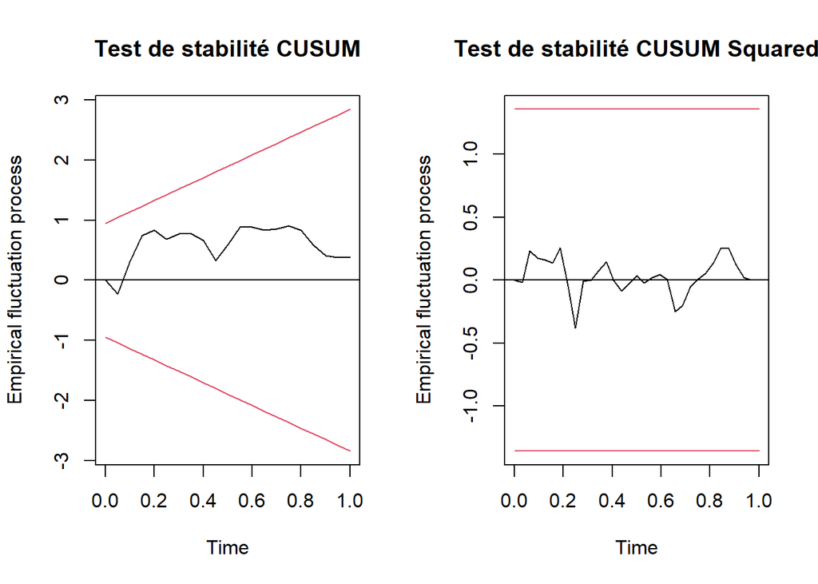

**Diagnoctic visuel**

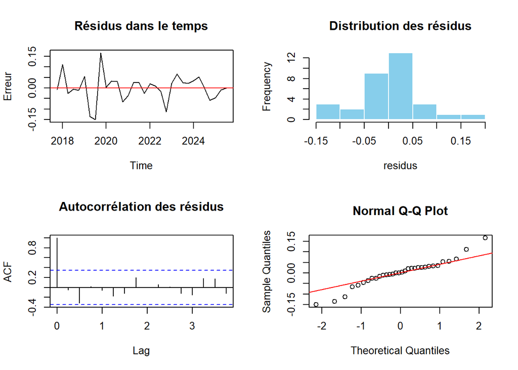

## 7.3 Lecture et analyse des rapports annuels des compagnies d’assurance

Dans cette partie, nous avons parcouru un ensemble de rapports sur la solvabilité et la situation financière de plusieurs compagnies d’assurance entre 2019 et 2025 afin d’approfondir la compréhension des mécanismes par lesquels les variables macroéconomiques et macro-financières affectent la solvabilité des assureurs. Nous nous sommes concentrés uniquement sur les parties des rapports annuels qui traitent de la solvabilité en nous focalisant sur :

- la variation des SCR, des fonds propres et des ratios de solvabilité ;
- la variation des variables macro-financières.

Dans un second temps, nous avons mis ces évolutions en relation avec la chronologie macroéconomique établie précédemment afin de mieux comprendre le lien entre la conjoncture économique et la situation des assureurs. Cette comparaison montre plusieurs éléments importants. D’abord, l’inflation pénalise particulièrement les assureurs non-vie, car elle augmente le coût des sinistres, des réparations et, plus généralement, des charges techniques. Elle réduit donc leurs marges, pèse sur le résultat net et peut aussi conduire à renforcer les provisions. Les assureurs vie sont également touchés, mais de façon différente : l’inflation diminue le rendement réel des placements et rend certains produits d’épargne concurrents plus attractifs, ce qui peut freiner la collecte et réduire la rentabilité des contrats.

Par ailleurs, cette analyse confirme que les taux d’intérêt jouent un rôle central dans la solvabilité des assureurs. Lorsque les taux restent bas, les placements obligataires rapportent moins et les engagements de long terme deviennent plus contraignants, surtout en assurance vie. À l’inverse, la remontée des taux peut alléger certaines charges d’actualisation, mais elle peut aussi entraîner des pertes de valeur sur les actifs détenus. Enfin, la volatilité des marchés financiers a elle aussi un impact important, car elle agit à la fois sur la valeur des actifs, sur les fonds propres et sur le capital requis. Ainsi, les rapports annuels confirment que la solvabilité des assureurs dépend fortement de l’environnement macro-financier, mais aussi de leur exposition aux différents risques et de leur capacité à absorber les chocs.

Ces éléments permettent d’apporter un premier éclairage sur la problématique étudiée et d’orienter l’analyse statistique qui sera menée par la suite, afin de faciliter l’interprétation des résultats.

## 7.4 Détail des variables qualitatives

### 7.4.1 Nature

Cette variable décrit l’activité d’assurance de la société :

- **Non Vie** : assurance dommages, automobile, habitation, santé, etc.
- **Vie/Capitalisation** : assurance vie, épargne et capitalisation.
- **Mixte** : compagnie présente à la fois sur les métiers Vie et Non-Vie.
- **Réassurance** : activité de réassurance.
- **FRPS** : fonds de retraite professionnelle supplémentaire.

### 7.4.2 Famille

Cette variable classe les assureurs selon leur modèle d’organisation :

- **Mutualiste** : assureur détenu par ses sociétaires, sans actionnaires, dont les résultats sont principalement réinvestis au service des assurés.
- **Traditionnel** : assureur organisé en société de capitaux, détenu par des actionnaires et orienté vers la rentabilité financière.
- **Bancassureur** : assureur intégré à un groupe bancaire, qui distribue ses produits principalement via le réseau bancaire.

Cette distinction est utile pour comparer les profils de solvabilité, car les contraintes financières et les sources de financement peuvent différer selon le modèle.

### 7.4.3 Remise

Cette variable indique la périodicité de la donnée :

- **T1, T2, T3, T4** : remises trimestrielles ;
- **A** : remise annuelle.

Dans le jeu de données, certaines années ne contiennent pas toutes les remises, ce qui traduit simplement des différences de disponibilité des données selon les périodes.

## 7.5 Les formules du SCR

Le SCR (*Solvency Capital Requirement*) représente l’exigence en fonds propres permettant à un assureur de faire face à ses risques sur un horizon d’un an avec une probabilité de 99,5 %, soit l’équivalent d’une faillite théorique tous les 200 ans. Les assureurs peuvent utiliser la formule standard définie par l’EIOPA, un modèle interne propre à leur structure de risque, ou une combinaison des deux (modèle partiel). Le SCR se décompose en trois termes :

$$SCR = BSCR + SCR_{op} - Adj$$

Le BSCR (*Basic SCR*) agrège les SCR par type de risque à l’aide d’une matrice de corrélation. L’Adj représente la capacité d’absorption des pertes par les provisions techniques et les impôts différés. Chaque SCR élémentaire correspond à la perte de fonds propres résultant d’un choc instantané calibré par l’EIOPA.

$$BSCR = \sqrt{\sum_{i,j} Corr_{i,j} \cdot
SCR_i \cdot SCR_j} + SCR_{intangibles}$$

Les coefficients $Corr_{i,j}$ de la formule du BSCR sont issus de la matrice suivante :

|  | Marché | Défaut | Sous. Vie | Sous. Santé | Sous. Non-vie |
| --- | --- | --- | --- | --- | --- |
| Marché | 1 | 0,25 | 0,25 | 0,25 | 0,25 |
| Défaut | 0,25 | 1 | 0,25 | 0,25 | 0,5 |
| Souscription Vie | 0,25 | 0,25 | 1 | 0,25 | 0 |
| Souscription Santé | 0,25 | 0,25 | 0,25 | 1 | 0 |
| Souscription Non-vie | 0,25 | 0,5 | 0 | 0 | 1 |

### 7.5.1 Risque de souscription

Le risque de souscription couvre l’incertitude sur les résultats des contrats, due notamment à des erreurs de tarification, de provisionnement ou à la survenance d’événements extrêmes. Il se divise en trois modules distincts, chacun calculé par agrégation matricielle de ses propres sous-risques :

$$SCR_{vie} = \sqrt{\sum_{(i,j)}
Corr^{Vie}_{i,j} \cdot SCR_i \cdot SCR_j}$$

$$SCR_{sant\acute{e}} = \sqrt{\sum_{(i,j)}
Corr^{Sant\acute{e}}_{i,j} \cdot SCR_i \cdot SCR_j}$$

$$SCR_{non-vie} = \sqrt{\sum_{(i,j)}
Corr^{NV}_{i,j} \cdot SCR_i \cdot SCR_j}$$

La matrice $Corr^{Vie}$ pour le risque vie comprend sept sous-risques. Les corrélations négatives, par exemple entre mortalité et longévité (−0,25), reflètent leur nature opposée : une hausse de la mortalité est défavorable pour les contrats décès mais favorable pour les rentes viagères, ce qui justifie une compensation partielle dans le calcul du SCR.

### 7.5.2 Matrice des sous-risques vie

|  | Mortalité | Longévité | Invalidité | Dépenses | Révision | Cessation | Catastrophe |
| --- | --- | --- | --- | --- | --- | --- | --- |
| Mortalité | 1 | -0,25 | 0,25 | 0,25 | 0 | 0 | 0,25 |
| Longévité | -0,25 | 1 | 0 | 0,25 | 0,25 | 0,25 | 0 |
| Invalidité | 0,25 | 0 | 1 | 0,5 | 0 | 0 | 0,25 |
| Dépenses | 0,25 | 0,25 | 0,5 | 1 | 0,5 | 0,5 | 0,25 |
| Révision | 0 | 0,25 | 0 | 0,5 | 1 | 0 | 0 |
| Cessation | 0 | 0,25 | 0 | 0,5 | 0 | 1 | 0,25 |
| Catastrophe | 0,25 | 0 | 0,25 | 0,25 | 0 | 0,25 | 1 |

### 7.5.3 Risque de marché

Le risque de marché mesure la sensibilité de l’assureur aux évolutions des marchés financiers (taux, actions, immobilier, devises, spreads). Il est calculé par agrégation matricielle de six sous-risques :

$$SCR_{march\acute{e}} =
\sqrt{\sum_{(i,j)} Corr^{March\acute{e}}_{i,j} \cdot SCR_i \cdot
SCR_j}$$

|  | Taux | Actions | Immobilier | Spread | Concentration | Devise |
| --- | --- | --- | --- | --- | --- | --- |
| Taux d’intérêt | 1 | A | A | A | 0 | 0,25 |
| Actions | A | 1 | 0,75 | 0,75 | 0 | 0,25 |
| Immobilier | A | 0,75 | 1 | 0,5 | 0 | 0,25 |
| Spread | A | 0,75 | 0,5 | 1 | 0 | 0,25 |
| Concentration | 0 | 0 | 0 | 0 | 1 | 0 |
| Devise | 0,25 | 0,25 | 0,25 | 0,25 | 0 | 1 |

Le paramètre $A$ vaut 0 si $SCR_{taux}$ est issu d’un choc à la hausse, 0,5 sinon.

### 7.5.4 Détail des formules et chocs par sous-risque

[output not shown]

### 7.5.5 Risque de défaut de contrepartie

Ce risque couvre la perte potentielle liée à la défaillance d’une contrepartie. Il se distingue du risque de spread, qui concerne la dégradation de la qualité de crédit des émetteurs de valeurs mobilières, et concerne exclusivement :

| Contrepartie | Description |
| --- | --- |
| Réassureurs | Défaut d’un réassureur sur ses engagements de couverture envers le cédant. C’est l’une des expositions les plus significatives pour les assureurs ayant fortement externalisé leur risque. |
| Banques dépositaires | Défaut d’un établissement bancaire détenant les actifs en dépôt. Cela concerne directement la valeur liquidative du portefeuille d’investissements de l’assureur. |
| Autres débiteurs | Intermédiaires d’assurance, preneurs, montants à recevoir au titre des créances sur contrats. Cela comprend aussi les débiteurs au titre des procédures de recours et subrogations. |

Dans la matrice BSCR, le risque de défaut présente une corrélation de 0,25 avec tous les autres modules, à l’exception de la souscription non-vie avec laquelle la corrélation est portée à 0,5, reflétant l’interdépendance entre la sinistralité et les défauts de réassureurs.